# Chemical Structures of PCBs congeners

Diwen Yang

29 September, 2022

```r
knitr::opts_chunk$set(
  echo = FALSE,
  message = FALSE,
  warning = FALSE,
  error = FALSE
)
```

# PCB Chemical properties

```
## # A tibble: 209 x 18
##    pcb      casrn biphe~1 categ~2    cid molec~3 molec~4 canon~5 isome~6 iupac~7
##    <chr>    <chr>   <dbl> <chr>    <dbl> <chr>     <dbl> <chr>   <chr>   <chr>
##  1 2-Chlor~ 2051~       1 Congen~ 249266 C12H9Cl    189. C1=CC=~ C1=CC=~ 1-chlo~
##  2 3-Chlor~ 2051~       2 Congen~  16322 C12H9Cl    189. C1=CC=~ C1=CC=~ 1-chlo~
##  3 4-Chlor~ 2051~       3 Congen~  16323 C12H9Cl    189. C1=CC=~ C1=CC=~ 1-chlo~
##  4 2,2'-Di~ 1302~       4 Congen~  25622 C12H8C~    223. C1=CC=~ C1=CC=~ 1-chlo~
##  5 2,3-Dic~ 1660~       5 Congen~  27959 C12H8C~    223. C1=CC=~ C1=CC=~ 1,2-di~
##  6 2,3'-Di~ 2556~       6 Congen~  33100 C12H8C~    223. C1=CC=~ C1=CC=~ 1-chlo~
##  7 2,4-Dic~ 3328~       7 Congen~  36399 C12H8C~    223. C1=CC=~ C1=CC=~ 2,4-di~
##  8 2,4'-Di~ 3488~       8 Congen~  36982 C12H8C~    223. C1=CC=~ C1=CC=~ 1-chlo~
##  9 2,5-Dic~ 3488~       9 Congen~  36980 C12H8C~    223. C1=CC=~ C1=CC=~ 1,4-di~
## 10 2,6-Dic~ 3314~      10 Congen~  36342 C12H8C~    223. C1=CC=~ C1=CC=~ 1,3-di~
## # ... with 199 more rows, 8 more variables: x_log_p <dbl>, exact_mass <dbl>,
## #   monoisotopic_mass <dbl>, tpsa <dbl>, h_bond_donor_count <dbl>,
## #   h_bond_acceptor_count <dbl>, volume3d <dbl>, fingerprint2d <chr>, and
## #   abbreviated variable names 1: biphenyl, 2: category, 3: molecular_formula,
## #   4: molecular_weight, 5: canonical_smiles, 6: isomeric_smiles, 7: iupac_name
```

# Making chemically aware table

Here’s the complete list of available PCBs, and their structures:

pcb

casrn

molecular_formula

x_log_p

structure

2-Chlorobiphenyl

2051-60-7

C12H9Cl

4.5

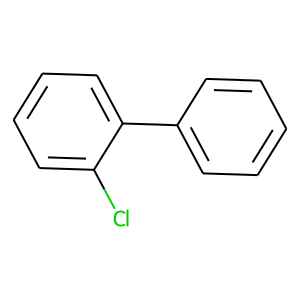

3-Chlorobiphenyl

2051-61-8

C12H9Cl

4.6

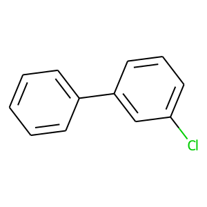

4-Chlorobiphenyl

2051-62-9

C12H9Cl

4.6

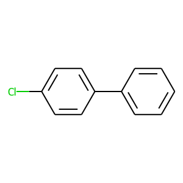

2,2'-Dichlorobiphenyl

13029-08-8

C12H8Cl2

5.0

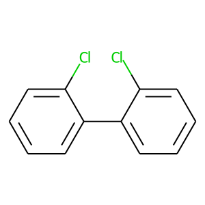

2,3-Dichlorobiphenyl

16605-91-7

C12H8Cl2

4.8

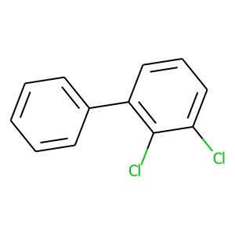

2,3'-Dichlorobiphenyl

25569-80-6

C12H8Cl2

5.0

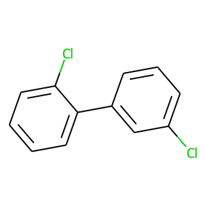

2,4-Dichlorobiphenyl

33284-50-3

C12H8Cl2

5.3

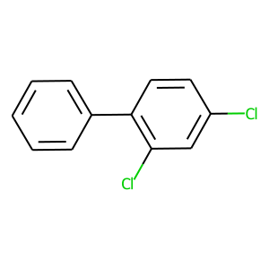

2,4'-Dichlorobiphenyl

34883-43-7

C12H8Cl2

5.1

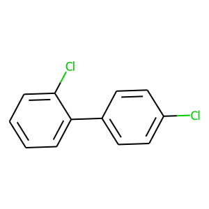

2,5-Dichlorobiphenyl

34883-39-1

C12H8Cl2

5.2

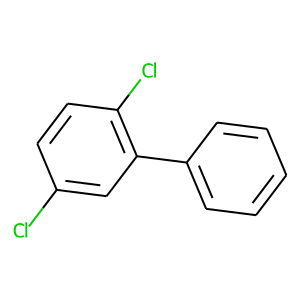

2,6-Dichlorobiphenyl

33146-45-1

C12H8Cl2

5.0

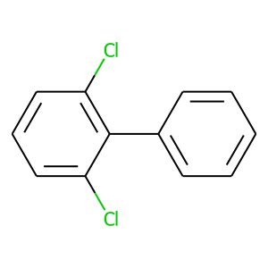

3,3'-Dichlorobiphenyl

2050-67-1

C12H8Cl2

5.2

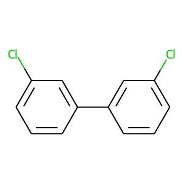

3,4-Dichlorobiphenyl

2974-92-7

C12H8Cl2

5.3

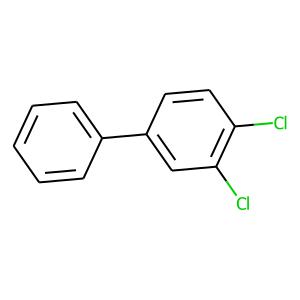

3,4'-Dichlorobiphenyl

2974-90-5

C12H8Cl2

5.2

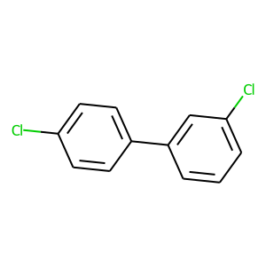

3,5-Dichlorobiphenyl

34883-41-5

C12H8Cl2

4.8

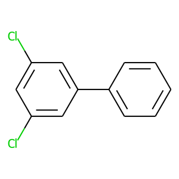

4,4'-Dichlorobiphenyl

2050-68-2

C12H8Cl2

5.6

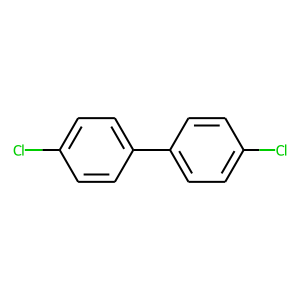

2,2',3-Trichlorobiphenyl

38444-78-9

C12H7Cl3

5.3

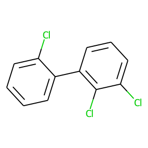

2,2',4-Trichlorobiphenyl

37680-66-3

C12H7Cl3

5.8

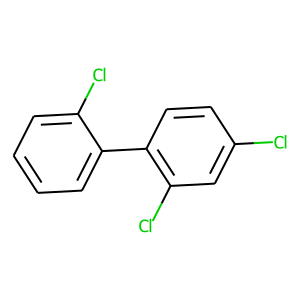

2,2',5-Trichlorobiphenyl

37680-65-2

C12H7Cl3

5.6

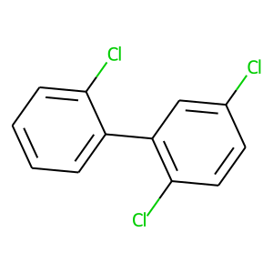

2,2',6-Trichlorobiphenyl

38444-73-4

C12H7Cl3

5.5

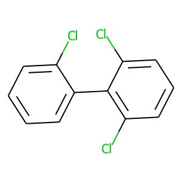

2,3,3'-Trichlorobiphenyl

38444-84-7

C12H7Cl3

5.6

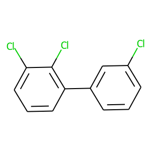

2,3,4-Trichlorobiphenyl

55702-46-0

C12H7Cl3

5.9

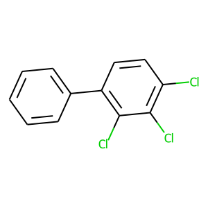

2,3,4'-Trichlorobiphenyl

38444-85-8

C12H7Cl3

5.4

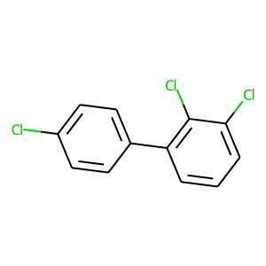

2,3,5-Trichlorobiphenyl

55720-44-0

C12H7Cl3

5.8

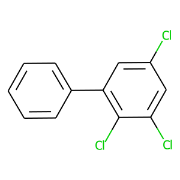

2,3,6-Trichlorobiphenyl

55702-45-9

C12H7Cl3

5.7

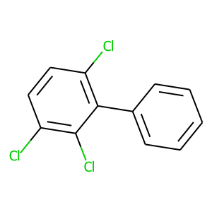

2,3',4-Trichlorobiphenyl

55712-37-3

C12H7Cl3

5.6

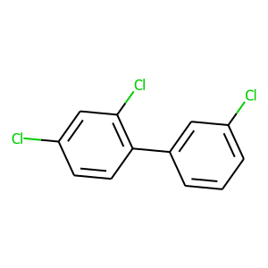

2,3',5-Trichlorobiphenyl

38444-81-4

C12H7Cl3

5.8

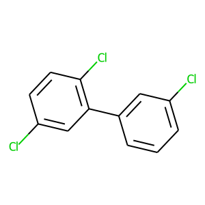

2,3',6-Trichlorobiphenyl

38444-76-7

C12H7Cl3

5.7

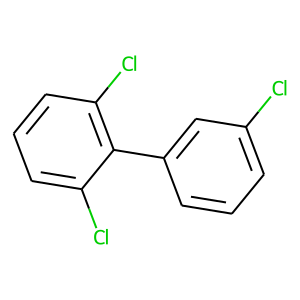

2,4,4'-Trichlorobiphenyl

7012-37-5

C12H7Cl3

5.6

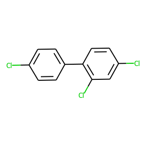

2,4,5-Trichlorobiphenyl

15862-07-4

C12H7Cl3

5.9

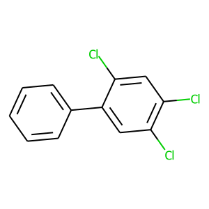

2,4,6-Trichlorobiphenyl

35693-92-6

C12H7Cl3

5.7

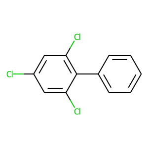

2,4',5-Trichlorobiphenyl

16606-02-3

C12H7Cl3

5.8

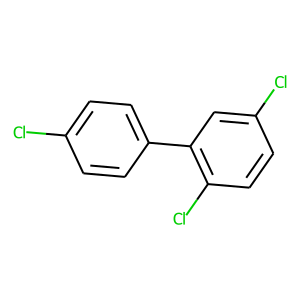

2,4',6-Trichlorobiphenyl

38444-77-8

C12H7Cl3